# Third Markdown Activity

Gian Nicole Villamayor

Jessica Dela Cruz

John Lester Santos

John Rollic Conducto

## SEMI INSULATING N-GALLIUM NITRIDE (GaN) ON SAPPHIRE SURFACE REFLECTION DATASET OBTAINED AT MILLIMETER WAVE FREQUENCIES 107.35–165 GHz

### **Introduction**

Since the rise of technological advancements, there has been an unending search for new products or discoveries that would enable electronic devices to exhibit better functionalities compared to their older versions.

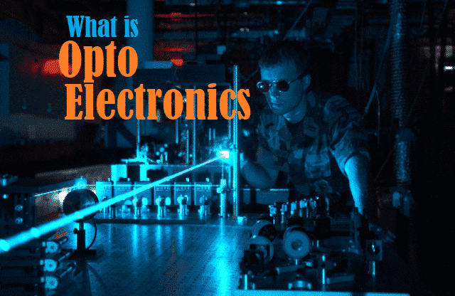

In optoelectronics, devices all depend on the use of certain elements in order to produce quality semiconductor doping results. For instance, adding small amounts of phosphorus turns silicon (Si) into a conductor for electrons (n-type), and adding small amounts of boron turns Si into a hole conductor (p-type). Light-emitting devices require the ability to dope material as both n-type and p-type, so that electrons and holes can be injected and transported to the active layer, where they recombine and emit light. Such ambipolar doping has been a longstanding problem in the wide-band-gap semiconductors that are used in short-wavelength light emitters (green, blue, or UV).

On the other hand, Silicon-doped N-Gallium Nitride (N-GaN) on sapphire with C-plane is an important electronic material used for sensors, amplifiers, power and control devices, and photoluminescence. 2-photon absorption (TPA) process is an important property of Ga-N wafers. TPA uses frequency dependent refractive indices which shows promising reflectance rate when evaluating dielectric and optical metrics property.

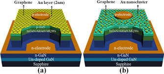

Gallium nitride is a sturdy and stable bandgap semiconductor that is used in the production of power devices as well as light emitting diodes (LED). In this study, the researchers aim to understand the behavior of the Semi insulating N-Gallium Nitride on sapphire surface reflection in different wave frequencies.

The voltage reflected from the Silicon-doped N-GaN sample will be compared with the initially undoped setup containing the voltage collected from the gold mirror. Their respected spectral response of ZBD voltage will be compared and analyzed in the unique probe range 107.35–165 GHz. The goal here is to see if the N-GaN reflection can effectively lower the voltage reflected when it is used for insulation.

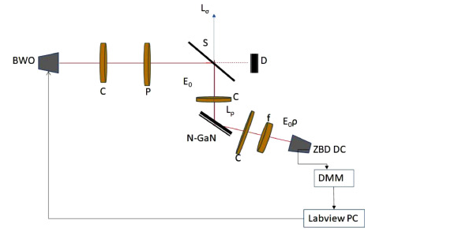

### **Methodology**

For the experimental part, the researchers collected voltages that signify real part of reflection coefficient spectra at a frequency resolution 100 MHz. These are the steps done in the acquisition of reflection voltage response data:

[interactive chart not shown]

**At first, a reference voltage spectrum is generated using the highly polished gold mirror reflector, and then, the mirror is replaced using the N-GaN on sapphire wafer and the sample reflection voltage spectrum is obtained likewise:**

1.Collection of gold mirror reflected (E0) spectral response of ZBD voltage from the swept BWO data between 107.35–165 GHz with resolution of 0.1 GHz and store data along with 10-sample standard deviation profile obtained from digital multimeter.

2.Mounting N-GaN sample and rotating sample holder by 24.6° while performing alignment tests so that maximum power is received.

3.Replace gold mirror with sample as shown in position for N-GaN in Fig. 1 and repeat step 1 for collection of sample E0ρ (reflected voltage) data as function of frequency and corresponding standard deviation data from digital multimeter also using LabVIEW.

4.Using statistics to compare the results and forming viable conclusions.

Table for Gathered Data (warning super long)

| Frequency in GHz | Reflected voltages for Au (V) | Standard Deviation…3 | (N-GaN) Doped | Standard Deviation…5 |
| --- | --- | --- | --- | --- |
| 110 | -0.192 | 9.06e-05 | -0.164 | 1.82e-04 |
| 110 | -0.174 | 5.06e-05 | -0.173 | 3.02e-04 |
| 110 | -0.164 | 1.20e-04 | -0.154 | 6.14e-05 |
| 110 | -0.163 | 7.15e-05 | -0.161 | 4.31e-05 |
| 110 | -0.156 | 1.17e-04 | -0.159 | 5.88e-05 |
| 111 | -0.148 | 4.87e-05 | -0.151 | 1.33e-04 |
| 111 | -0.155 | 5.45e-05 | -0.145 | 7.05e-05 |
| 111 | -0.142 | 3.83e-05 | -0.152 | 6.24e-05 |
| 111 | -0.162 | 4.65e-05 | -0.157 | 1.07e-04 |
| 111 | -0.164 | 5.80e-05 | -0.163 | 6.55e-05 |
| 111 | -0.167 | 5.43e-05 | -0.164 | 4.76e-05 |
| 111 | -0.163 | 6.55e-05 | -0.156 | 4.88e-05 |
| 111 | -0.174 | 4.79e-05 | -0.152 | 5.17e-05 |
| 111 | -0.154 | 5.68e-05 | -0.153 | 4.30e-05 |
| 111 | -0.160 | 4.47e-05 | -0.147 | 5.21e-05 |
| 112 | -0.154 | 4.68e-05 | -0.139 | 4.37e-05 |
| 112 | -0.152 | 5.73e-05 | -0.138 | 4.06e-05 |
| 112 | -0.153 | 3.09e-05 | -0.137 | 4.71e-05 |
| 112 | -0.165 | 5.15e-05 | -0.137 | 4.41e-05 |
| 112 | -0.160 | 3.85e-05 | -0.141 | 3.33e-05 |
| 112 | -0.164 | 4.66e-05 | -0.142 | 4.42e-05 |
| 112 | -0.150 | 5.63e-05 | -0.135 | 4.40e-05 |
| 112 | -0.156 | 3.97e-05 | -0.143 | 4.66e-05 |
| 112 | -0.161 | 5.36e-05 | -0.138 | 4.21e-05 |
| 112 | -0.176 | 4.48e-05 | -0.157 | 4.14e-05 |
| 113 | -0.171 | 4.43e-05 | -0.148 | 4.00e-05 |
| 113 | -0.180 | 4.08e-05 | -0.150 | 5.64e-05 |
| 113 | -0.175 | 3.95e-05 | -0.148 | 4.09e-05 |
| 113 | -0.174 | 5.16e-05 | -0.157 | 3.75e-05 |
| 113 | -0.177 | 4.28e-05 | -0.157 | 3.88e-05 |

[output cut: 471 more lines]

### **Results and Discussion**

**1. Parameter of interest:** The quantity of interest is the difference in mean reflection voltage, $μ_1 − μ_2$, and $Δ_0 = 0$.

**2. Null hypothesis:** $H_0: μ_1 − μ_2 = 0,$ or $H_0: μ_1 = μ_2.$

**5. Reject** $H_0:μ_1 = μ_2$ **if:** Using α =0.05 and a fixed-significance-level test, we would reject $H_0:μ_1 = μ_2$ if $t^*_0 < -t_{0.05,967} = -1.65$.

**6. Computations:**

```r
t.test(test1$Au,test1$GaN, mu=0, alt="less", conf=0.95, var.equal=F, paired=F)
```

```
##
##  Welch Two Sample t-test
##
## data:  test1$Au and test1$GaN
## t = -13.399, df = 967.01, p-value < 2.2e-16
## alternative hypothesis: true difference in means is less than 0
## 95 percent confidence interval:
##         -Inf -0.02600202
## sample estimates:
##  mean of x  mean of y
## -0.2463134 -0.2166687
```

**7. Conclusion:** Because $t^*_0 = -13.399<-t_{0.05,967} = -1.65$, $H_0$ is rejected at the $α = 0.05$ level.

### **References**

[1] D. Montgomery and G. Runger, Applied statistics and probability for engineers, 7th ed. Wiley, 2017, pp. 262–279.

[2] B. Roy, M. H. Wu, and B. Vlahovic, “Semi insulating n-gallium nitride (GaN) on sapphire surface reflection DATASET obtained at millimeter wave Frequencies 107.35–165 ghz,” Data in Brief, 17-Oct-2020. [Online]. Available: https://www.sciencedirect.com/science/article/pii/S2352340920313019?fbclid=IwAR1imNj78uBMeJ69A3ROEZN0KcKsRXL5lVvC50iPklANJh2n7wcg_BaSpZY. [Accessed: 28-Jul-2021].

[3] J. L. Lyons, A. Janotti, and C. G. Van de Walle, “Shedding light on doping of Gallium Nitride,” Research Gate, July-2012. [Online]. Available: https://www.researchgate.net/publication/314859390_Shedding_light_on_doping_of_gallium_nitride. [Accessed: 4-Aug-2021].

[4] R. Cunningham, “First Fun with RMarkdown,” RPubs. [Online]. Available: https://rpubs.com/redrobincl/241336. [Accessed: 29-Jul-2021].

[5] “T.Test: Student’s t-test,” RDocumentation. [Online]. Available: https://www.rdocumentation.org/packages/stats/versions/3.6.2/topics/t.test?fbclid=IwAR3X-DEeIaCng1ExhSWLP1CDcgXD0HdZbfbrKdnvb2LiLp343cl9Jgk9sbE. [Accessed: 30-Jul-2021].

[6] Z.Sun, “How to Use Tabbed Sections in Rmarkdown,” RPubs. [Online]. Available: https://rpubs.com/sunzhe96/596831#:~:text=To%20implement%20the%20tabbed%20section,file%20to%20an%20html%20file. [Accessed: 29-Jul-2021].